# Class 6: Aspects of Social Movement Activity

Organisation, strategies and tactics

[Dr. Michael C. Zeller](https://michaelzeller.de)

# Opening notes

[Open Sticker](https://tenor.com/view/open-gif-14209777)from [Open Stickers](https://tenor.com/search/open-stickers)

## Presentation groups

Presentations line-up

[output not shown]

# A conceptual framework of *strategy*

- strategy defined
- elements of strategy
- drivers of strategy selection
- example from a non-violent but disruptive group
- example from a violent group

[Strategery Snl Skit GIF](https://tenor.com/view/strategery-snl-skit-will-ferrell-strategy-gw-bush-gif-14201105381996209314)from [Strategery GIFs](https://tenor.com/search/strategery-gifs)

## Basic, intuitive definition of *strategy*

strategy refers to the approach of an actor(s) to achieve their (political) objectives—connecting actions to goals (*means* to an *end*)

- extant definitions identify some elements, e.g.,
  - “a combination of a claim (or demand), a tactic, and a site (or venue)” (Meyer 2007, 82)
  - Ganz (2010, 9): targeting, tactics, timing
- many groups use mixed strategies of violence and non-violence

## Elements of strategy

- informative element: objective(s) (*why*): what are the actor(s) goals? minimalist vs. maximalist objectives
- target (what/who) - what entity is being acted upon?
  - involves choice to commit resources to specific outcomes
- tactics (how) - types of collective action and their form
  - attempt to deploy *strengths*, exploit target’s *weaknesses*
- site/venue (where) - what place or what forum type is action taken?
- timing (when) - when are tactics employed against targets
  - ‘some moments, often fleeting, promise greater opportunity than others’ … (cf. Grzymala-Busse 2011)

## Elements of strategy

- informative element: objective(s) (*why*): what are the actor(s) goals? minimalist vs. maximalist objectives
- target (what/who) - what entity is being acted upon?
- tactics (how) - types of collective action and their form
- site/venue (where) - what place or what forum type is action taken?
- timing (when) - when are tactics employed against targets

**What are the strategic elements of social movements that you know of?**

## Drivers of strategy selection

- strategy is be a product of (rational) choice

BUT…

- it is also a part collective identity (cf. Polletta and Jasper 2001)
  - strategy also involves *moral and emotional committments*

## An example from the news…

**How can we characterise the group’s *strategy* here?**

[video not shown]

*Tagesschau*  
https://www.youtube.com/watch?v=eT9nr9_em0k&pp=ygUebGFzdCBnZW5lcmF0aW9uIHByb3Rlc3QgYmVybGlu

## An example from ‘the 43 Group’

[video not shown]

## An example from ‘the 43 Group’

post-war Labour government, witnessing low-level fascist-party organising and agitation…

Beckman (2013):

> On Tuesday May 21st [1946], [James] Chuter Ede, the Home Secretary, received a deputation from the JDC [Jewish Defence Committee, part of the Board of Deputies of British Jews] led by the Chairman, Gordon Liverman … They listened to the deputation and said they would consider all the points raised, but nothing tangible happened.

documentary about 43 Group: https://www.youtube.com/watch?v=oBusQBSCAHY

# Open data - ACLED protest repertoires

[interactive chart not shown]

| month | Protests | Strategic developments | Explosions/Remote violence | Riots | Battles | Violence against civilians |
| --- | --- | --- | --- | --- | --- | --- |
| 2020-01-01 | 366 | 20 | 2 | 14 | 1 | 1 |
| 2020-02-01 | 453 | 33 | 1 | 13 | 0 | 5 |
| 2020-03-01 | 135 | 24 | 0 | 4 | 1 | 3 |
| 2020-04-01 | 174 | 27 | 0 | 5 | 0 | 2 |
| 2020-05-01 | 630 | 14 | 0 | 25 | 0 | 1 |
| 2020-06-01 | 391 | 18 | 2 | 16 | 0 | 3 |
| 2020-07-01 | 310 | 26 | 0 | 8 | 0 | 2 |
| 2020-08-01 | 252 | 16 | 0 | 17 | 0 | 3 |
| 2020-09-01 | 475 | 20 | 0 | 17 | 0 | 2 |
| 2020-10-01 | 394 | 42 | 1 | 18 | 0 | 2 |

[output cut: 53 more lines]

**Data download**

# Open data - POLDEM protest repertoires

- Visualisation
- Explanatory note
- Data table

[interactive chart not shown]

Data source: Kriesi et al. 2020, [PolDem-Protest Dataset](https://poldem.eui.eu/) 30 European Countries, Version 1. The stacked bars show the monthly composition of `action_form` (the protest repertoire), and the black line (right-hand axis) overlays the share of events per month coded as `radical_action` (confrontational or violent, vs. not radical). You can see both which tactics are used and how confrontational the overall repertoire is at any point in time.

| month | Blockades/confrontations | Demonstrations | Other | Petitions/symbolic | Strikes | Violent protest | pct_radical |
| --- | --- | --- | --- | --- | --- | --- | --- |
| 2000-01-01 | 44 | 83 | 13 | 21 | 33 | 54 | 39.5161290322581 |
| 2000-02-01 | 15 | 131 | 3 | 23 | 37 | 26 | 17.4468085106383 |
| 2000-03-01 | 11 | 89 | 6 | 21 | 27 | 27 | 20.9944751381215 |
| 2000-04-01 | 5 | 61 | 2 | 11 | 16 | 21 | 22.4137931034483 |
| 2000-05-01 | 4 | 65 | 5 | 9 | 34 | 31 | 23.6486486486486 |
| 2000-06-01 | 6 | 64 | 9 | 8 | 34 | 37 | 27.2151898734177 |
| 2000-07-01 | 16 | 75 | 13 | 15 | 13 | 84 | 46.2962962962963 |
| 2000-08-01 | 22 | 69 | 3 | 21 | 4 | 79 | 51.010101010101 |
| 2000-09-01 | 239 | 135 | 15 | 10 | 47 | 47 | 58.0121703853955 |
| 2000-10-01 | 56 | 125 | 7 | 13 | 29 | 47 | 37.1841155234657 |

[output cut: 182 more lines]

**Data download**

# Poll: strategy formation and effect

[figure not shown]

Take the survey at **https://forms.gle/6aVSF54HyFR2iNpDA**

- most important factor shaping strategy?
- maximalist goals require extreme strategies?
- is popular support necessary for strategic success?
- political engagement necessary for big impact?
- disruptive tactics an effective way of generating awareness?

Questions about movements: (1) movement’s organisational form? (2) movement relies on formal coordination structures (meetings, committees, roles)? (3) leadership plays a visible and strategic role in guiding the movement? (4) movement’s main strategic orientation? (5) movement mainly uses conventional, legally permitted forms of protest? (6) movement’s primary tactic of mobilisation?

[interactive chart not shown]

most important factor shaping movement org. strategy?

[interactive chart not shown]

do maximalist goals require more extreme strategies?

[interactive chart not shown]

## Poll results

popular support necessary for strategic success?

[interactive chart not shown]

engagement in politics necessary for long-term impact?

[interactive chart not shown]

disrupting is effective for building awareness?

[interactive chart not shown]

## Tactical frivolity (Bogad 2016)

more of a humanities/dramaturgical perspective on movements and their tactics

[video not shown]

# Temporality

- Grzymala-Busse (2011) on temporality
  - overview
  - definitions and examples
  - tempo and duration

[Timing GIF](https://tenor.com/view/timing-good-timing-on-time-clock-looking-at-the-clock-gif-12086181)from [Timing GIFs](https://tenor.com/search/timing-gifs)

## Grzymala-Busse (2011) - overview

- mechanisms: “recurrent causal links between specified initial conditions and outcomes. Specific sequences (orderings) of mechanisms and events then constitute processes.”
- Fundamentals of temporality: how long events take (**duration**), how quickly they change (**tempo**), whether they speed up or slow down (**acceleration**), and when they occur (**timing**)

## Grzymala-Busse (2011) - definitions and examples

| Aspect | Definition | Examples |
| --- | --- | --- |
| Duration | Temporal length of an event; how much time elapses between the start and end of an action or event | Time elapsed between the announcement that a new agency is founded and its demise, or the period between the takeoff of popular literacy and its full attainment |
| Tempo | Amount of change per unit of time (dist./time interval); frequency of the 'subevents' in a larger event, or between events in a process. | How much time elapses before each new state institution is established, between each new person gaining literacy |
| Acceleration (and deceleration) | Derivative of velocity with respect to time (direction vector/direction tempo); rate of change | Postcommunist privatization started to unfold very quickly, with a great deal of entrepreneurial activity and privatization auctions at the outset. In several countries, it then slowed down |
| Timing | Position on a temporal timeline (itself composed of some units of time, such as electoral cycles or years) | 18th-century revolutions had pamphlets and word of mouth as their mobilizing techniques; 20th-century revolutions had television, radio, email, and cell phones at their disposal |

## Grzymala-Busse (2011) - tempo and duration

|  | Faster | Slower |
| --- | --- | --- |
| Shorter | Radical processes: coups, revolutions, shock therapy, regime replacement, and some institutional creation (free elections) | Abruptly ending processes: threshold effects, bargaining, establishing some institutions (cf. postcommunist clientelism) |
| Longer | Lengthy instability: revolutions and wars, cascades, predation, postcommunist civil society growth, political party fission | Gradual processes: demographic change, spread of literacy and nationalism, linguistic transformations, quasiparameter change |

# Tactics and effecting change

- connecting tactics to outcomes
- tactical innovation
- Spaßguerrillas
- Gene Sharp and nonviolence
- some fun examples

[Talladega Nights GIF](https://tenor.com/view/talladega-nights-tactics-cal-gif-22419743)from [Talladega GIFs](https://tenor.com/search/talladega-gifs)

## Connecting tactics to outcomes

- Gamson (1990) found that violent social movements (incl. ‘strikes and disruptive techniques’) are more likely than nonviolent to achieve their goal
  - more effective in attracting attention and imposing costs on targets/opponents
  - similarly found by Cress and Snow (2000)
  - BUT… opposite found on regime-challenging movements by Chenoweth and Stephan (2011)
  - Opposite also found in U.S. campus policy by Rojas (2006)

## Connecting tactics to outcomes

- **social control hypothesis** (e.g., Piven and Cloward 1979)
  - disruptive protests/tactics allow movements to win concessions in exchange for ending protests/tactics (*coercion* mechanism)
- **mass mobilisation/social pressure hypothesis** (e.g., Chenoweth and Stephan 2011)
  - gaining enough (visible) support to pressure decision-makers into concessions (*consensus/demonstrative/persuasion* mechanisms)
    - implicit appeal to democratic norms

## (necessity of) tactical innovation

- McAdam (1983): tactical interaction
  - movements *disrupt* as they mount a challenge
  - authorities/targets *adapt* to tactics, dulling their impact
  - movements *innovate* tactics to maintain effective strategy
- With responsive authorities/targets, **this cycle places high demands on movements**
  - (McAdam (1983) writes that by the end of the 1960s, U.S. black rights movement(s) had been made ‘*tactically impotent*’)

## Spaßguerrillas

- problem in student movement of unexciting and/or intimidating modes of activism
- Wolfgang Lefèvre (SDS leader):

> ‘Every event or demonstration should be inventively planned so that it is exciting and fun for students.’
- the ‘fun-fighters’ emerged from the *Sozialistischen Deutschen Studentenbund*
  - Fritz Teufel, Rainer Langhans advocate **playful tactics**
  - long legacy in German activism (e.g., ‘Front Deutscher Äpfel’)

## Gene Sharp and nonviolence (Sharp 1973)

- ‘*political ju-jitsu*’ (using opponents’ strength against them): violent repression of nonviolent resistance strengthens resistance by creating sympathy for resisters

$\downarrow$

- accumulation of [198 methods of nonviolent action](https://www.brandeis.edu/peace-conflict/pdfs/198-methods-non-violent-action.pdf), e.g.:
  - many famous types: demonstrations, strikes, pickets
  - some less known options: prisoners’ strike, slow compliance, ‘Lysistratic nonaction’
    - **any ideas what these mean / examples?**
- check out the list for more types of tactics: https://nvdatabase.swarthmore.edu/browse-methods

## Tactics in practice, example

- off and on since 1988, German neo-Nazi groups had organised ‘memorial marches’ in **Wunsiedel** (Virchow 2013; Zeller 2022)
- in 2014, anti-far-right activists organised ‘involuntary walkathon’

[video not shown]

(German version: https://www.youtube.com/watch?v=mMrQge9hP5o)

## Tactics in practice, example

- 2016: U.S. state of Texas passes law allowing carrying handguns on university campuses
- at the same time, state ‘obsenity laws’ forbid bringing dildoes onto campus
- the ‘cocks not glocks’ campaign was born…

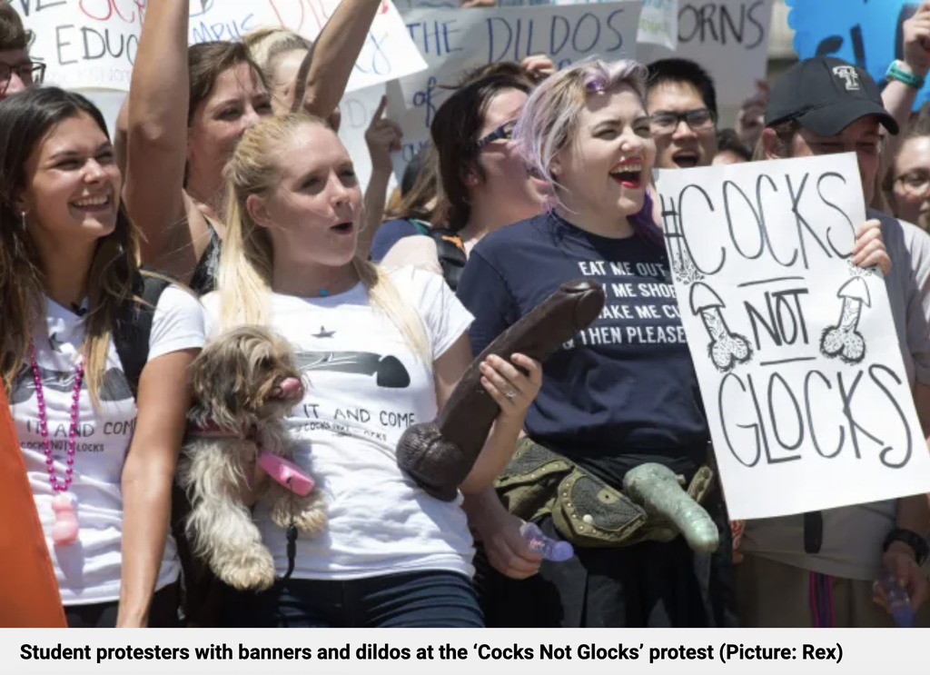

## Tactics in practice, example

‘We’re fighting absurdity with absurdity.’

[video not shown]

## Movement responses - org. form

movement’s organisational form?

[interactive chart not shown]

## Movement responses - structure and leaders

movement relies on formal structures?

[interactive chart not shown]

leadership has visible and strategic role?

[interactive chart not shown]

## Movement responses - strategy

movement’s main strategic orientation?

[interactive chart not shown]

## Movement responses - legal protest

movement mainly uses legally permitted protest?

[interactive chart not shown]

## Movement responses - tactics

movement’s primary tactic of mobilisation?

[interactive chart not shown]

# Any feedback for this class?

Anonymous feedback here: https://forms.gle/AjHt6fcnwZxkSg4X8

Alternatively, please send me an email: m.zeller@lmu.de

Questions about movements next meeting: (1) Which type of media is most important for the movement’s visibility? (2) Does the movement strategically plan actions to generate media coverage? (3) Is media coverage of the movement generally favourable? (4) Which audience is the movement mainly trying to influence? (5) Does the movement often succeed in getting its narratives spread through the media? (6) How successful has the movement been at influencing public debate?

## References

Beckman, Morris. 2013. *The 43 Group: Battling with Mosley’s Blackshirts*. New York: Perseus Press.

Bogad, Lawrence M. 2016. *Tactical Performance*. London: Routledge.

Chenoweth, Erica, and Maria J. Stephan. 2011. *Why Civil Resistance Works: The Strategic Logic of Nonviolent Conflict*. New York: Columbia University Press.

Cress, Daniel, and David Snow. 2000. “The Outcomes of Homeless Mobilization: The Influence of Organization, Disruption, Political Mediation, and Framing.” *American Journal of Sociology* 105 (4): 1063–1104.

Gamson, William A. 1990. *The Strategy of Social Protest*. Belmont: Wadsworth Publishing.

Ganz, Marshall. 2010. *Why David Sometimes Wins: Leadership, Organization, and Strategy in the California Farm Worker Movement*. Oxford: Oxford University Press.

Grzymala-Busse, Anna. 2011. “Time Will Tell? Temporality and the Analysis of Causal Mechanisms and Processes.” *Comparative Political Studies* 44 (9): 1267–97. https://doi.org/10.1177/0010414010390653.

McAdam, Doug. 1983. “Tactical Innovation and the Pace of Insurgency.” *American Sociological Review* 48 (6): 735–54.

Piven, Francis Fox, and Richard A Cloward. 1979. *Poor People’s Movements*. New York: Vintage Books.

Polletta, Francesca, and James M Jasper. 2001. “Collective Identity and Social Movements.” *Annual Review of Sociology* 27 (1): 283–305.

Rojas, Fabio. 2006. “Social Movement Tactics, Organizational Change and the Spread of African-American Studies.” *Social Forces* 84 (4): 2147–66.

Sharp, Gene. 1973. *The Politics of Nonviolent Action (3 Vols.)*. New York: Porter Sargent.

Virchow, Fabian. 2013. “’Wem Die Strasse Gehört’: Wunsiedel Als Symbolischer Ort Der Demonstrationspolitik Der Extremen Rechten.” In *Wunsiedel Ist Bunt – Nicht Braun! Die Auseinandersetzungen Um Das Hess-Grab Verändern Die Politische Kultur*, edited by Julia Hasse, Gregor Rosenthal, and Joachim Twisselmann, 171–85. Bad Alexandersbad/Berlin: bfdt/BPgR.

Zeller, Michael C. 2022. “Demobilising Far-Right Demonstration Campaigns: Coercive Counter-Mobilisation, State Social Control, and the Demobilisation of the Hess Gedenkmarsch Campaign.” *Social Movement Studies* 21 (3): 372–90. https://doi.org/10.1080/14742837.2021.1889493.